# Pembangkitan Arma Responsi

Jonathan Marjono

2023-09-21

## White Noise

Pembangkitan data berpola AR, MA, ARMA, dan banyak proses deret waktu lainnya diawali pembangkitan *white noise*. *White noise* merupakan sederet nilai dari peubah bebas stokastik identik. Oleh karena itu, *white noise* memiliki dua karakteristik penting:

1. *White noise* tidak memiliki autokorelasi (**karena saling bebas**)
2. Nilai harapan dan ragam *white noise* sama (**karena berasal dari peubah acak bebas stokastik identik**)

*White noise* dibangkitkan dari suatu peubah acak, umumnya peubah acak normal.

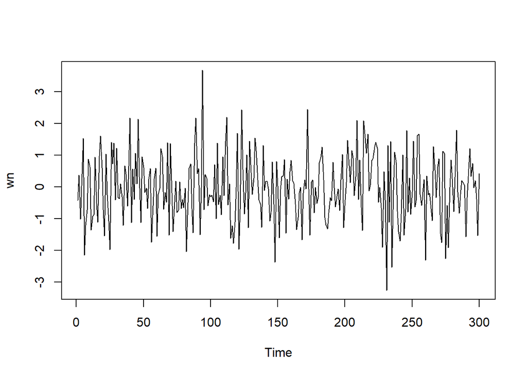

```r
wn <- rnorm(300)
ts.plot(wn)
```

Dapat terlihat bahwa *white noise* tidak memiliki autokorelasi dari ACF. Perhatikan bahwa lag ke-0 adalah korelasi observasi ke-t dengan dirinya sendiri. Nilai korelasi tersebut pasti 1. Sebagai alternatif, lag pertama di plot ACF dapat ditetapkan sebagai 1 (alih-alih 0) dengan menambahkan argumen `xlim(1, lag akhir)`. Plot tersebut dapat disandingkan bersamaan dengan membuat matriks $1 \times 2$ dengan `par(mfrow = c(1,2))`

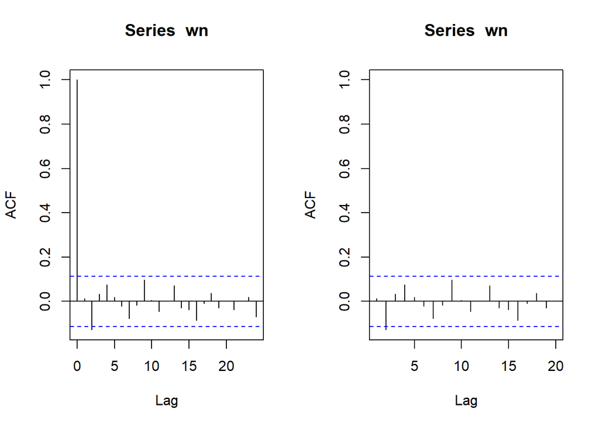

```r
par(mfrow = c(1, 2))
acf(wn)
acf(wn, xlim = c(1, 20))
```

## Proses MA(2)

Proses MA dapat dituliskan sebagai berikut:

$$y_{t} = c + e_t + \theta_{1}e_{t-1} + \theta_{2}e_{t-2} + \dots +
\theta_{q}e_{t-q} = c+{e_t+\sum_{i=1}^p \theta_ie_{t-i}}$$
Terlihat bahwa $e_t$, atau *white noise*, berperan penting dalam pembangkitan proses MA.

Akan dicoba membangkitkan proses MA(2) dengan $\theta_1 = 0.4$ dan $\theta_2=0.6$ sebanyak 300 observasi dan $c=0$. Karena diperlukan dua nilai awal untuk $e_{t-1}$ serta $e_{t-2}$, masukkan nilai pertama dan kedua white noise sebagai nilai awal tersebut.

### Pembangkitan secara manual

```r
set.seed(064)
ma <- wn[c(1,2)]
```

```r
for(i in 3:300){
   ma[i] <- wn[i] + 0.4 * wn[i - 1] + 0.6 * wn[i-2]
}
ma
```

```
##   [1] -0.4159944523  0.3785410726 -1.1019147486 -0.1369746777  0.9517275852
##   [6] -1.5005665392 -1.1377215828 -2.4838573091 -0.1319440575  0.5531968848
##  [11] -0.5683455613 -1.0862470212 -2.0570756152  0.0333605047 -0.6634026745
##  [16] -0.7520865942  0.2250732246  1.3301552655  1.8410689544  0.4914730610
##  [21] -1.4527013122 -0.0045177241 -0.7437747310 -0.5362538334 -2.5444680062
##  [26] -0.0129663862  0.1164253479  2.5251100616  0.5960553013  1.8986780680
##  [31] -0.0714871660  0.2385778225 -0.2399272331 -0.4872145251 -1.2639923122
##  [36]  0.0005033203 -0.0395973802 -0.0307505320  0.6698821235  2.0780263292
##  [41]  0.1472311795  1.4275041587 -0.8314363221  1.2574786916  0.3009680166
##  [46]  2.8207127072  1.2436053197  0.2893439053  0.6990976383  0.3315859126
##  [51]  0.6512981228  0.2718384502 -0.7878594940 -0.0342197352  0.2792687273
##  [56] -1.3462555415 -0.9295176442 -1.0045656979  0.3523733973 -1.1563233014
##  [61] -0.5000422745 -1.0748983834  1.0490604835  1.4247759885  0.4105990257
##  [66]  0.1373828265 -0.9702111116  1.1047194073 -1.2487714445  1.5995597069
##  [71] -0.5459773593 -0.6565298230 -1.3684430861 -0.9324470920 -1.1399958682
```

[output cut: 45 more lines]

### Pembangkitan dengan arima.sim

Selain menggunakan cara di atas, pembangkitan proses MA(2) dapat dilakukan dengan fungsi `arima.sim()` sebagai berikut.

```r
set.seed(064)
ma2 <- arima.sim(list(order=c(0,0,2), ma=c(0.4,0.6)), n=300)
ma2
```

```
## Time Series:
## Start = 1
## End = 300
## Frequency = 1
##   [1] -3.051635563 -0.023641980 -0.173530536  0.604841802  0.831821899
##   [6] -0.132940954  1.899366383  1.596838388  1.805987669 -0.644129334
##  [11] -1.144083776 -0.800134991 -1.702532003 -2.461891565 -1.919277410
##  [16] -0.617201231  0.002184546 -0.468115490  0.059511904  0.484179157
##  [21]  1.660043055  0.984216067  1.121609224  0.297215792 -0.430801189
##  [26] -1.359530105 -2.084834816 -0.687248070 -0.620923544  1.727112470
##  [31]  0.592946232  3.650558280  1.750083140  2.489655664  0.093556222
##  [36] -0.516328980  0.099364816  0.356771968 -1.566258102 -0.843772015
##  [41] -0.098610984 -0.605346027  0.416139084  0.776543147  0.883483468
##  [46]  0.983351965  0.255244155 -0.003179645  2.423158053  0.769562632
##  [51]  1.439417283 -0.689855090  1.732900335  0.109694487  1.805228985
```

[output cut: 49 more lines]

## Karakteristik MA(2)

### Plot time series

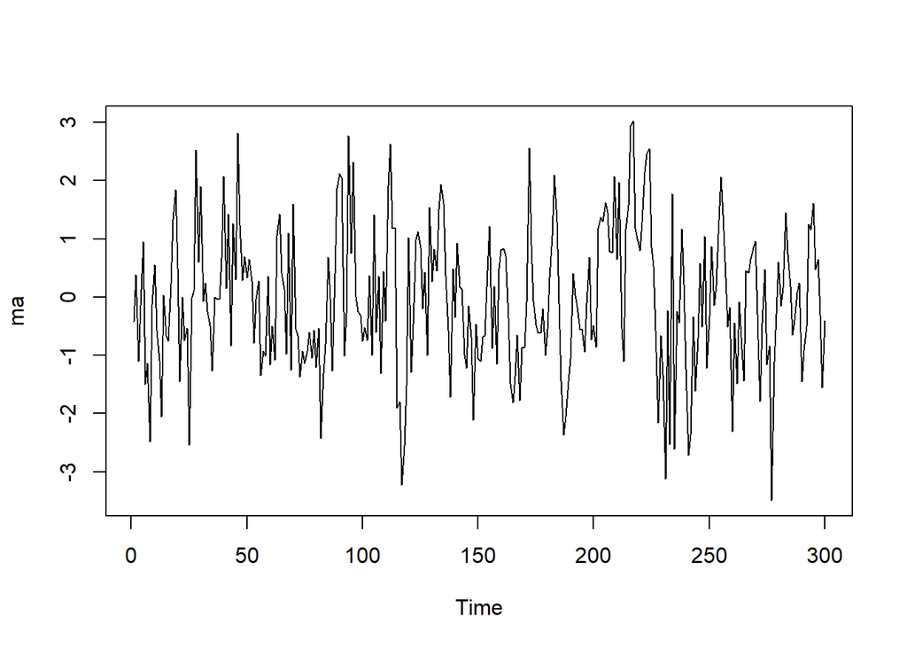

```r
ts.plot(ma)
```

Berdasarkan plot time series, terlihat bahwa data MA(2) yang dibangkitkan stasioner dalam rataan

### Plot ACF

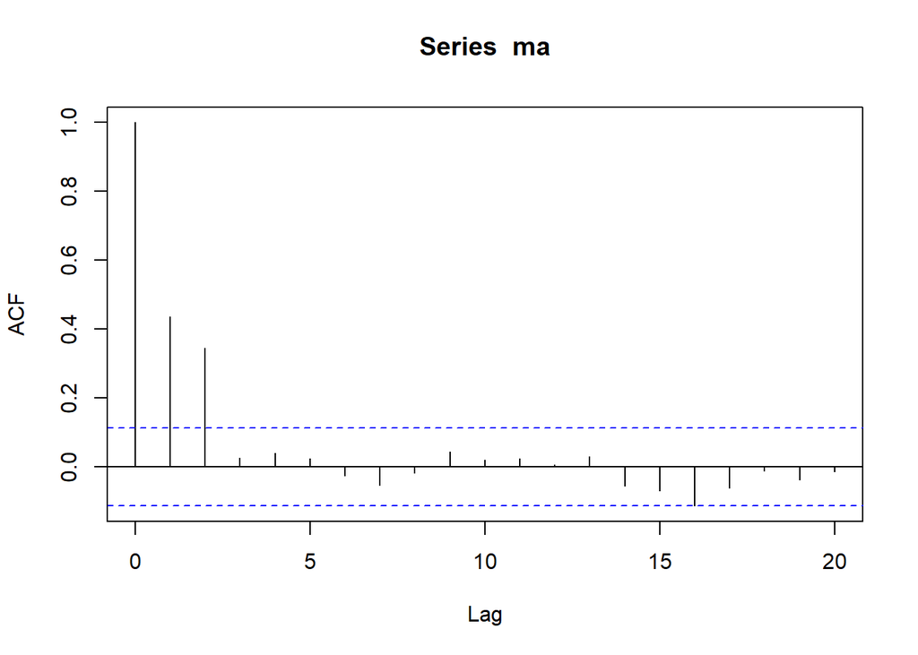

```r
acf(ma,lag.max = 20)
```

Berdasarkan plot AFC tersebut, terlihat bahwa plot ACF *cuts off* di lag kedua

### Plot PCAF

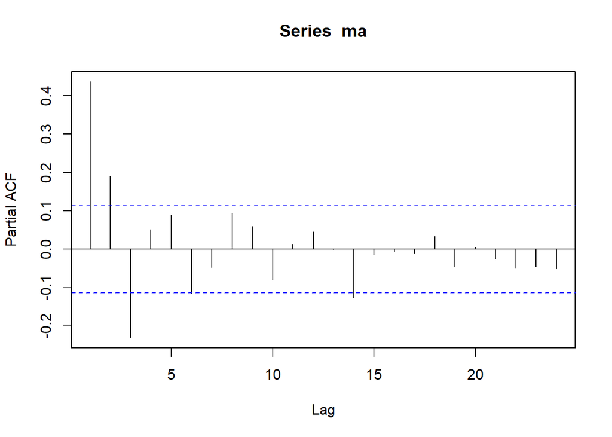

```r
pacf(ma)
```

Berdasarkan plot PACF tersebut, terlihat bahwa plot PACF cenderung *tails off* dan membentuk gelombang sinus

### Plot EACF

```r
TSA::eacf(ma)
```

```
## AR/MA
##   0 1 2 3 4 5 6 7 8 9 10 11 12 13
## 0 x x o o o o o o o o o  o  o  o
## 1 x x x o o o o o o o o  o  o  o
## 2 x x x x o o o o o o o  o  o  o
## 3 x x o x o o o o o o o  o  o  o
## 4 x x x x o o o o o o o  o  o  o
## 5 x x x x o o o o o o o  o  o  o
## 6 x x x o o o o o o o o  o  o  o
## 7 x x o o x o o o o o o  o  o  o
```

Berdasarkan pola segitiga nol pada plot EACF, terlihat bahwa segitiga nol berada pada ordo AR(0) dan ordo MA(2)

Data tersebut statsioner berdasarkan plot time series yang dibuat

## Scatterplot antar lag untuk MA(2)

### $Y_t$ dengan $Y_{t-1}$

```r
#Yt
yt_ma <- ma[-1]
yt_ma
```

```
##   [1]  0.3785410726 -1.1019147486 -0.1369746777  0.9517275852 -1.5005665392
##   [6] -1.1377215828 -2.4838573091 -0.1319440575  0.5531968848 -0.5683455613
##  [11] -1.0862470212 -2.0570756152  0.0333605047 -0.6634026745 -0.7520865942
##  [16]  0.2250732246  1.3301552655  1.8410689544  0.4914730610 -1.4527013122
##  [21] -0.0045177241 -0.7437747310 -0.5362538334 -2.5444680062 -0.0129663862
##  [26]  0.1164253479  2.5251100616  0.5960553013  1.8986780680 -0.0714871660
##  [31]  0.2385778225 -0.2399272331 -0.4872145251 -1.2639923122  0.0005033203
##  [36] -0.0395973802 -0.0307505320  0.6698821235  2.0780263292  0.1472311795
##  [41]  1.4275041587 -0.8314363221  1.2574786916  0.3009680166  2.8207127072
##  [46]  1.2436053197  0.2893439053  0.6990976383  0.3315859126  0.6512981228
##  [51]  0.2718384502 -0.7878594940 -0.0342197352  0.2792687273 -1.3462555415
##  [56] -0.9295176442 -1.0045656979  0.3523733973 -1.1563233014 -0.5000422745
##  [61] -1.0748983834  1.0490604835  1.4247759885  0.4105990257  0.1373828265
##  [66] -0.9702111116  1.1047194073 -1.2487714445  1.5995597069 -0.5459773593
##  [71] -0.6565298230 -1.3684430861 -0.9324470920 -1.1399958682 -0.9238697359
```

[output cut: 45 more lines]

```r
#Yt-1
yt_1_ma <- ma[-300]
yt_1_ma
```

```
##   [1] -0.4159944523  0.3785410726 -1.1019147486 -0.1369746777  0.9517275852
##   [6] -1.5005665392 -1.1377215828 -2.4838573091 -0.1319440575  0.5531968848
##  [11] -0.5683455613 -1.0862470212 -2.0570756152  0.0333605047 -0.6634026745
##  [16] -0.7520865942  0.2250732246  1.3301552655  1.8410689544  0.4914730610
##  [21] -1.4527013122 -0.0045177241 -0.7437747310 -0.5362538334 -2.5444680062
##  [26] -0.0129663862  0.1164253479  2.5251100616  0.5960553013  1.8986780680
##  [31] -0.0714871660  0.2385778225 -0.2399272331 -0.4872145251 -1.2639923122
##  [36]  0.0005033203 -0.0395973802 -0.0307505320  0.6698821235  2.0780263292
##  [41]  0.1472311795  1.4275041587 -0.8314363221  1.2574786916  0.3009680166
##  [46]  2.8207127072  1.2436053197  0.2893439053  0.6990976383  0.3315859126
##  [51]  0.6512981228  0.2718384502 -0.7878594940 -0.0342197352  0.2792687273
##  [56] -1.3462555415 -0.9295176442 -1.0045656979  0.3523733973 -1.1563233014
##  [61] -0.5000422745 -1.0748983834  1.0490604835  1.4247759885  0.4105990257
##  [66]  0.1373828265 -0.9702111116  1.1047194073 -1.2487714445  1.5995597069
##  [71] -0.5459773593 -0.6565298230 -1.3684430861 -0.9324470920 -1.1399958682
```

[output cut: 45 more lines]

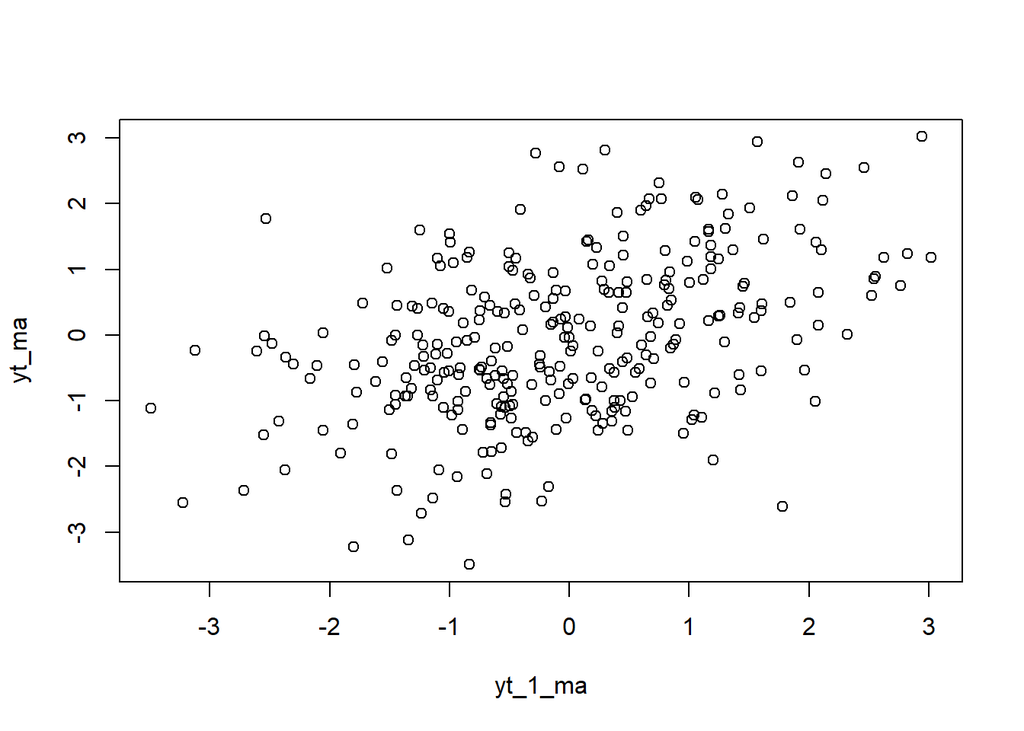

```r
plot(y=yt_ma,x=yt_1_ma)
```

Berdasarkan scatterplot tersebut, terlihat bahwa terdapat hubungan positif antara $Y_t$ dengan $Y_{t-1}$. Hal ini sesuai dengan teori yang ada

### $Y_t$ dengan $Y_{t-2}$

```r
yt_ma2 <- ma[-c(1,2)]
yt_ma2
```

```
##   [1] -1.1019147486 -0.1369746777  0.9517275852 -1.5005665392 -1.1377215828
##   [6] -2.4838573091 -0.1319440575  0.5531968848 -0.5683455613 -1.0862470212
##  [11] -2.0570756152  0.0333605047 -0.6634026745 -0.7520865942  0.2250732246
##  [16]  1.3301552655  1.8410689544  0.4914730610 -1.4527013122 -0.0045177241
##  [21] -0.7437747310 -0.5362538334 -2.5444680062 -0.0129663862  0.1164253479
##  [26]  2.5251100616  0.5960553013  1.8986780680 -0.0714871660  0.2385778225
##  [31] -0.2399272331 -0.4872145251 -1.2639923122  0.0005033203 -0.0395973802
##  [36] -0.0307505320  0.6698821235  2.0780263292  0.1472311795  1.4275041587
##  [41] -0.8314363221  1.2574786916  0.3009680166  2.8207127072  1.2436053197
##  [46]  0.2893439053  0.6990976383  0.3315859126  0.6512981228  0.2718384502
##  [51] -0.7878594940 -0.0342197352  0.2792687273 -1.3462555415 -0.9295176442
##  [56] -1.0045656979  0.3523733973 -1.1563233014 -0.5000422745 -1.0748983834
##  [61]  1.0490604835  1.4247759885  0.4105990257  0.1373828265 -0.9702111116
##  [66]  1.1047194073 -1.2487714445  1.5995597069 -0.5459773593 -0.6565298230
##  [71] -1.3684430861 -0.9324470920 -1.1399958682 -0.9238697359 -0.6044011903
```

[output cut: 45 more lines]

```r
#Yt-2
yt_2_ma <- ma[-c(299,300)]
yt_2_ma
```

```
##   [1] -0.4159944523  0.3785410726 -1.1019147486 -0.1369746777  0.9517275852
##   [6] -1.5005665392 -1.1377215828 -2.4838573091 -0.1319440575  0.5531968848
##  [11] -0.5683455613 -1.0862470212 -2.0570756152  0.0333605047 -0.6634026745
##  [16] -0.7520865942  0.2250732246  1.3301552655  1.8410689544  0.4914730610
##  [21] -1.4527013122 -0.0045177241 -0.7437747310 -0.5362538334 -2.5444680062
##  [26] -0.0129663862  0.1164253479  2.5251100616  0.5960553013  1.8986780680
##  [31] -0.0714871660  0.2385778225 -0.2399272331 -0.4872145251 -1.2639923122
##  [36]  0.0005033203 -0.0395973802 -0.0307505320  0.6698821235  2.0780263292
##  [41]  0.1472311795  1.4275041587 -0.8314363221  1.2574786916  0.3009680166
##  [46]  2.8207127072  1.2436053197  0.2893439053  0.6990976383  0.3315859126
##  [51]  0.6512981228  0.2718384502 -0.7878594940 -0.0342197352  0.2792687273
##  [56] -1.3462555415 -0.9295176442 -1.0045656979  0.3523733973 -1.1563233014
##  [61] -0.5000422745 -1.0748983834  1.0490604835  1.4247759885  0.4105990257
##  [66]  0.1373828265 -0.9702111116  1.1047194073 -1.2487714445  1.5995597069
##  [71] -0.5459773593 -0.6565298230 -1.3684430861 -0.9324470920 -1.1399958682
```

[output cut: 45 more lines]

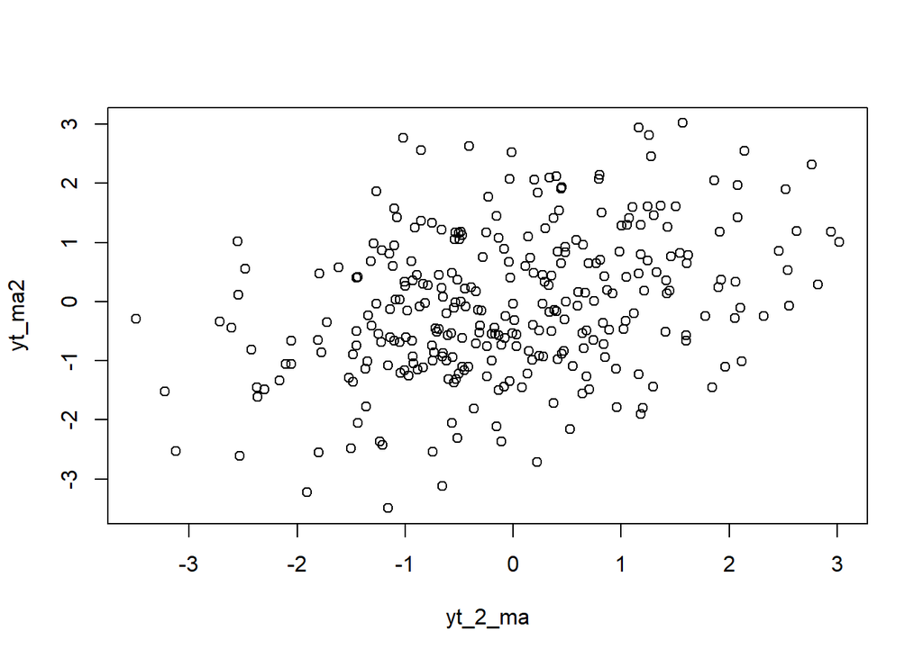

```r
plot(y=yt_ma2,x=yt_2_ma)
```

Berdasarkan scatterplot tersebut, terlihat bahwa terdapat hubungan positif antara $Y_t$ dengan $Y_{t-2}$

### $Y_t$ dengan $Y_{t-3}$

```r
yt_ma3 <- ma[-c(1,2,3)]
yt_ma3
```

```
##   [1] -0.1369746777  0.9517275852 -1.5005665392 -1.1377215828 -2.4838573091
##   [6] -0.1319440575  0.5531968848 -0.5683455613 -1.0862470212 -2.0570756152
##  [11]  0.0333605047 -0.6634026745 -0.7520865942  0.2250732246  1.3301552655
##  [16]  1.8410689544  0.4914730610 -1.4527013122 -0.0045177241 -0.7437747310
##  [21] -0.5362538334 -2.5444680062 -0.0129663862  0.1164253479  2.5251100616
##  [26]  0.5960553013  1.8986780680 -0.0714871660  0.2385778225 -0.2399272331
##  [31] -0.4872145251 -1.2639923122  0.0005033203 -0.0395973802 -0.0307505320
##  [36]  0.6698821235  2.0780263292  0.1472311795  1.4275041587 -0.8314363221
##  [41]  1.2574786916  0.3009680166  2.8207127072  1.2436053197  0.2893439053
##  [46]  0.6990976383  0.3315859126  0.6512981228  0.2718384502 -0.7878594940
##  [51] -0.0342197352  0.2792687273 -1.3462555415 -0.9295176442 -1.0045656979
##  [56]  0.3523733973 -1.1563233014 -0.5000422745 -1.0748983834  1.0490604835
##  [61]  1.4247759885  0.4105990257  0.1373828265 -0.9702111116  1.1047194073
##  [66] -1.2487714445  1.5995597069 -0.5459773593 -0.6565298230 -1.3684430861
##  [71] -0.9324470920 -1.1399958682 -0.9238697359 -0.6044011903 -1.0457543783
```

[output cut: 45 more lines]

```r
#Yt-3
yt_3_ma <- ma[-c(298,299,300)]
yt_3_ma
```

```
##   [1] -0.4159944523  0.3785410726 -1.1019147486 -0.1369746777  0.9517275852
##   [6] -1.5005665392 -1.1377215828 -2.4838573091 -0.1319440575  0.5531968848
##  [11] -0.5683455613 -1.0862470212 -2.0570756152  0.0333605047 -0.6634026745
##  [16] -0.7520865942  0.2250732246  1.3301552655  1.8410689544  0.4914730610
##  [21] -1.4527013122 -0.0045177241 -0.7437747310 -0.5362538334 -2.5444680062
##  [26] -0.0129663862  0.1164253479  2.5251100616  0.5960553013  1.8986780680
##  [31] -0.0714871660  0.2385778225 -0.2399272331 -0.4872145251 -1.2639923122
##  [36]  0.0005033203 -0.0395973802 -0.0307505320  0.6698821235  2.0780263292
##  [41]  0.1472311795  1.4275041587 -0.8314363221  1.2574786916  0.3009680166
##  [46]  2.8207127072  1.2436053197  0.2893439053  0.6990976383  0.3315859126
##  [51]  0.6512981228  0.2718384502 -0.7878594940 -0.0342197352  0.2792687273
##  [56] -1.3462555415 -0.9295176442 -1.0045656979  0.3523733973 -1.1563233014
##  [61] -0.5000422745 -1.0748983834  1.0490604835  1.4247759885  0.4105990257
##  [66]  0.1373828265 -0.9702111116  1.1047194073 -1.2487714445  1.5995597069
##  [71] -0.5459773593 -0.6565298230 -1.3684430861 -0.9324470920 -1.1399958682
```

[output cut: 45 more lines]

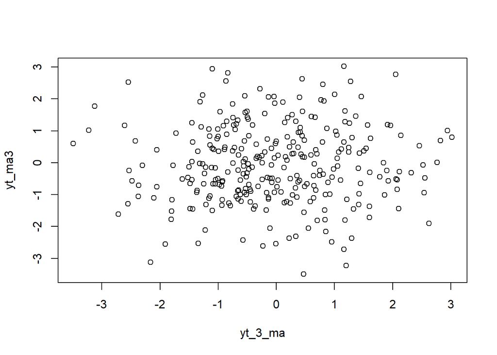

```r
plot(y=yt_ma3,x=yt_3_ma)
```

Berdasarkan scatterplot tersebut, terlihat bahwa cenderung tidak terdapat hubungan antara $Y_t$ dengan $Y_{t-3}$.

## Autokorelasi pada MA(2)

```r
cor(yt_ma,yt_1_ma)
```

```
## [1] 0.4362525
```

```r
cor(yt_ma2,yt_2_ma)
```

```
## [1] 0.3451635
```

```r
cor(yt_ma3,yt_3_ma)
```

```
## [1] 0.02506901
```

Korelasi antara $Y_t$ dengan $Y_{t-1}$ dari hasil simulasi mendekati perhitungan teoritis yaitu
$$\rho_1=\frac{-\theta_1+\theta_1\theta_2}{1+\theta_1^2+\theta_2^2}=\frac{-(-0.4)+0.4\times0.6}{1+(-0.4)^2+(-0.6)^2}=0.42$$

Korelasi antara $Y_t$ dengan $Y_{t-2}$ dari hasil simulasi mendekati perhitungan teoritis yaitu
$$\rho_2=\frac{-\theta_2}{1+\theta_1^2+\theta_2^2}=\frac{-(-0.6)}{1+(-0.4)^2+(-0.6)^2}=0.39$$

Korelasi antara $Y_t$ dengan $Y_{t-3}$ hasil simulasi mendekati teori yang ada yaitu 0.
$$\rho_3=0$$

## Plot, Scatterplot, Autokorelasi: MA(2) dengan ARIMA.SIM

### Plot ARIMA.SIM MA(2)

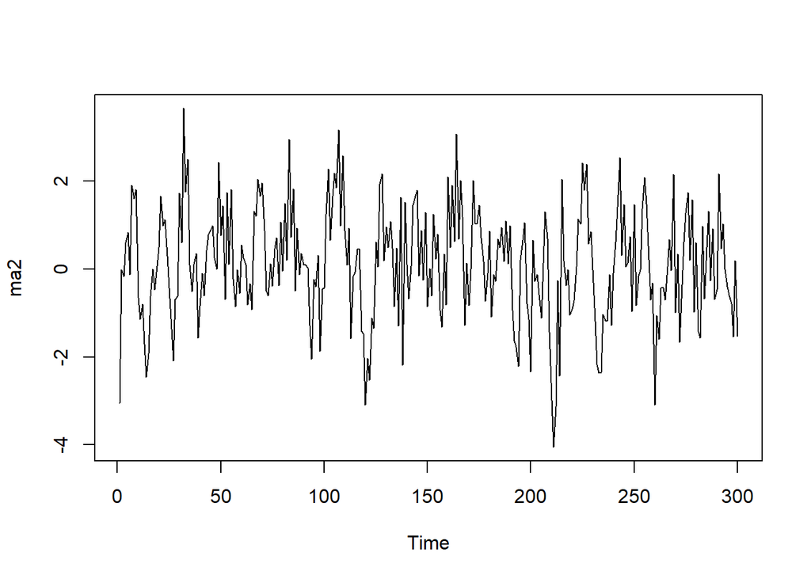

```r
ts.plot(ma2) #Plot Time Series
```

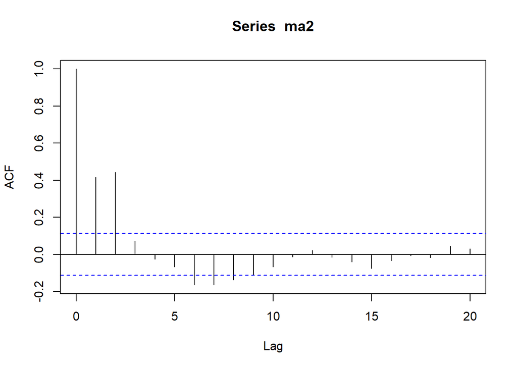

```r
acf(ma2,lag.max = 20) #Plot ACF
```

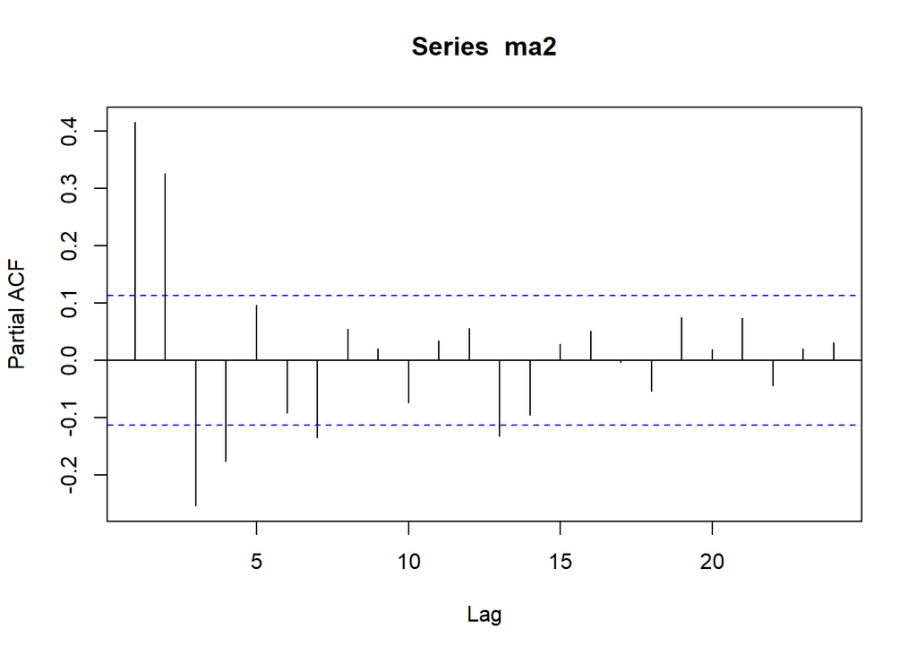

```r
pacf(ma2) #Plot PACF
```

```r
TSA::eacf(ma2) #Plot EACF
```

```
## AR/MA
##   0 1 2 3 4 5 6 7 8 9 10 11 12 13
## 0 x x o o o x x x o o o  o  o  o
## 1 x x x o o o o o o o o  o  o  o
## 2 x x x o o o o o o o o  o  o  o
## 3 x x x o x o o o o o o  o  o  o
## 4 x o x o o o o o o o o  o  o  o
## 5 x o x x o o o o o o o  o  o  o
## 6 x x x x o o o o o o o  o  o  o
## 7 x x x x o o o o o o o  o  o  o
```

### Scattlerplot dan autokorelasi antar lag ARIMA.SIM MA(2)

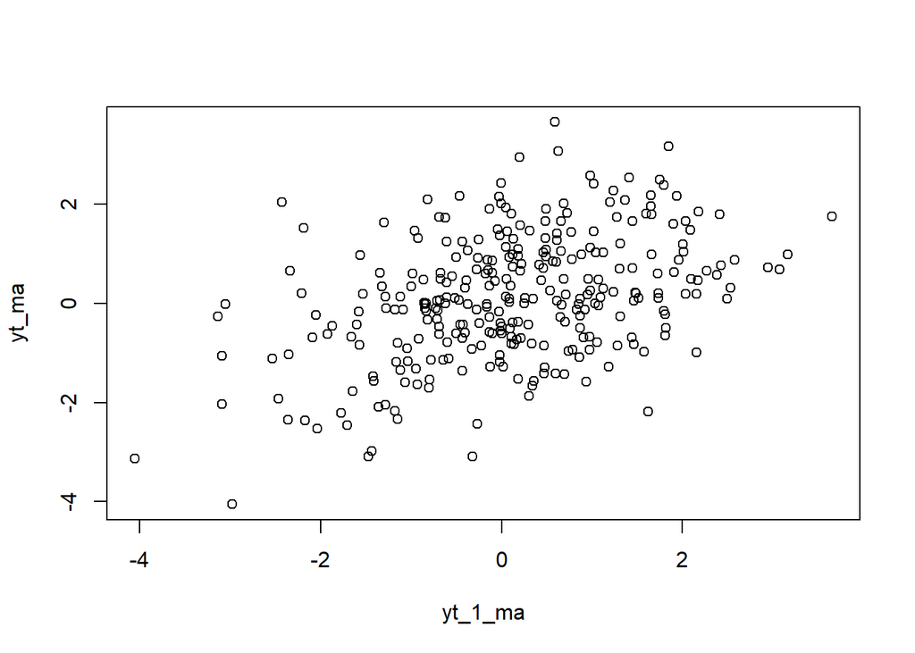

```r
#Korelasi antara Yt dengan Yt−1
yt_ma <- ma2[-1]
yt_1_ma <- ma2[-300]
plot(y=yt_ma,x=yt_1_ma)
```

```r
cor(yt_ma,yt_1_ma)
```

```
## [1] 0.4211175
```

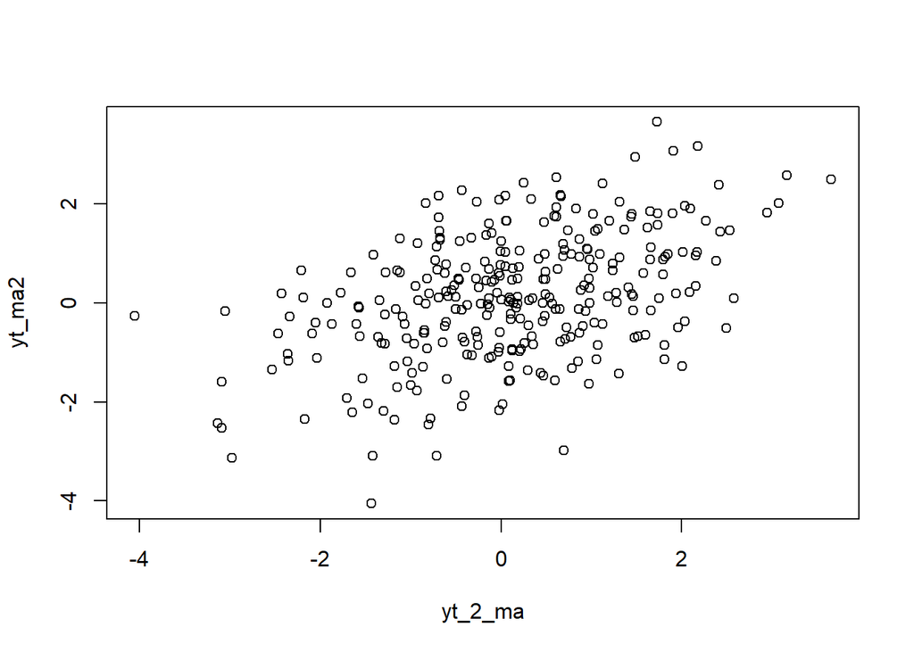

```r
#Korelasi antara Yt dengan Yt−2
yt_ma2 <- ma2[-c(1,2)]
yt_2_ma <- ma2[-c(299,300)]
plot(y=yt_ma2,x=yt_2_ma)
```

```r
cor(yt_ma2,yt_2_ma)
```

```
## [1] 0.4491009
```

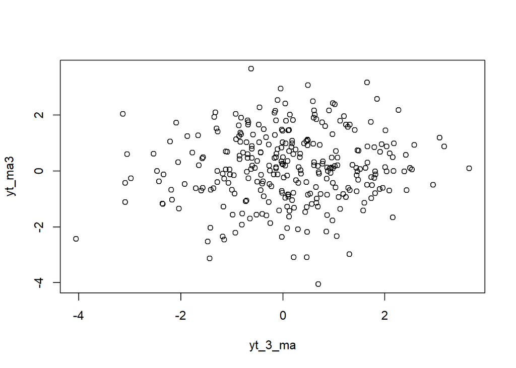

```r
#Korelasi antara Yt dengan Yt−3
yt_ma3 <- ma2[-c(1,2,3)]
yt_3_ma <- ma2[-c(298,299,300)]
plot(y=yt_ma3,x=yt_3_ma)
```

```r
cor(yt_ma3,yt_3_ma)
```

```
## [1] 0.07319074
```

## Proses AR(2)

Proses AR dapat dituliskan sebagai berikut:

$$y_{t} = c + e_t + \phi_{1}Y_{t-1} +
\phi_{2}Y_{t-2} + \dots + \phi_{q}Y_{t-q} = c+{e_t+\sum_{i=1}^p
\phi_iY_{t-i}}$$
Terlihat bahwa $Y_t$ berperan penting dalam pembangkitan proses AR.

Akan dicoba membangkitkan AR(2) dengan $\phi_1 = 0.5$ dan $\phi_2=0.2$ sebanyak 300 observasi dan $c=0$.

```r
set.seed(064)
```

Nilai-nilai selanjutnya dapat dicari melalui *loop*. Bentuk loop dapat dilihat dari rumus AR(2) yang hendak dibangkitkan:
$$Y_t = e_t+0.5Y_{t-1}+0.2Y_{t-2}$$

### Pembangkitan secara manual

```r
n<-length(wn)
n
```

```
## [1] 300
```

```r
ar <- c(1:n)
for (i in 3:n) {ar[i]<-wn[i]+0.5*ar[i-1]+0.2*ar[i-2]}
ar
```

```
##   [1]  1.000000000  2.000000000  0.196265494  0.535527228  1.846027209
##   [6] -1.108488376 -1.390723656 -1.635478393 -0.217049483  0.197094020
##  [11] -1.293594891 -1.533761525 -1.902883000 -0.318090266 -1.052695868
##  [16] -1.700885051 -0.083696368  1.223767377  1.207525142  0.131561274
##  [21] -1.226062174  0.452275443 -0.258438451 -1.102669040 -2.578310013
##  [26] -0.094197138  0.172640787  1.449135478  0.361248578  1.699275673
##  [31]  0.597579062  0.269651311  0.356596671 -0.074491996 -1.168583860
##  [36]  0.066408226  0.215244856 -0.475508598  0.464287355  2.309318817
##  [41]  0.130441706  1.098052729  0.185536243  1.383107876  0.835084597
##  [46]  2.829869691  1.907420711  0.397417130  1.532915843  1.469798304
##  [51]  0.871603779  0.695237243 -0.150183269  0.319299722  0.710017959
##  [56] -1.312754863 -1.099484820 -0.543840416  0.104241627 -1.612465871
##  [61] -1.020734724 -0.880127713  0.564966621  1.075923094 -0.051738687
##  [66]  0.026096329 -0.480606971  1.160889514 -1.032853136  1.084597401
##  [71]  0.152518187 -1.111374934 -1.221879581 -0.644251464 -1.364065391
```

[output cut: 45 more lines]

```r
ar2 <- arima.sim(list(order=c(2,0,0), ar=c(0.5,0.2)), n=300)
ar2
```

```
## Time Series:
## Start = 1
## End = 300
## Frequency = 1
##   [1]  0.7078189114 -0.1717854546 -1.0453286075 -1.7629111716 -0.6348136686
##   [6] -0.7496618018  0.9837633451  0.3884763925  3.1316041252  2.2694189289
##  [11]  2.3559493626  1.1118941067  0.3618422461  1.0807612485  1.0977133274
##  [16] -1.4017116723 -0.7493755041  0.6536162144 -0.7910341412 -0.2466556652
##  [21]  1.0685335095  0.8175089244  0.6627429057  0.5344607147  0.3565952576
##  [26]  2.7018688113  1.2510546817  1.2237904728  0.2518145999  2.3129487368
##  [31]  0.9057933820  1.6757629801  0.6751242383 -0.4953435649  0.5457285137
##  [36]  0.0625563145  0.3309939185  0.4302745877  0.1740603033 -0.7520513753
##  [41] -0.2347182320 -0.6751931648  1.0279538838  1.2542836093  1.6712031979
##  [46]  1.8756312425  2.4102179692  1.5208275059  0.0794224072  0.2393881210
##  [51]  0.9979110878 -0.1244855661  0.3508175931  1.1707443802 -0.2555360385
```

[output cut: 49 more lines]

## Karakteristik AR(2)

### Plot times series

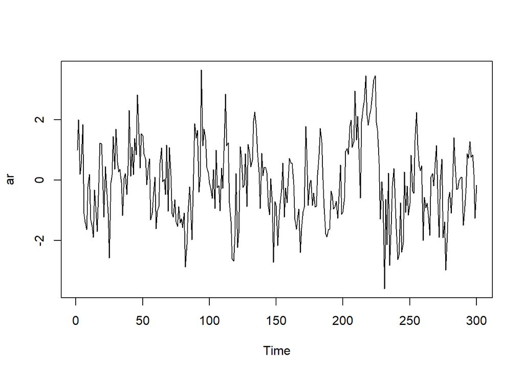

```r
ts.plot(ar)
```

Berdasarkan plot time series tersebut terlihat bahwa data cenderung stasioner pada rataan

### Plot ACF

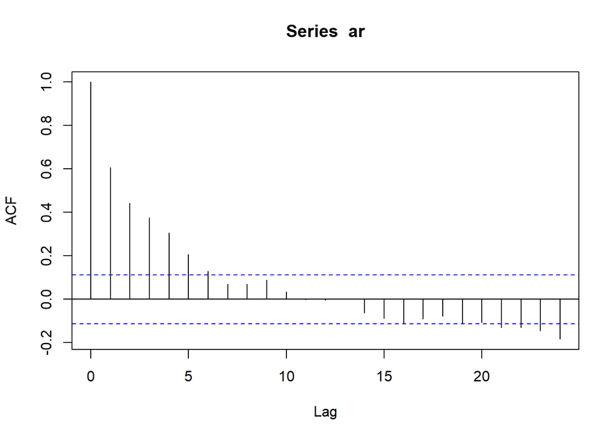

```r
acf(ar)
```

Berdasarkan plot ACF tersebut terlihat bahwa plot ACF cenderung *tails off* dan cenderung membentuk pola grafik sinus

### Plot PACF

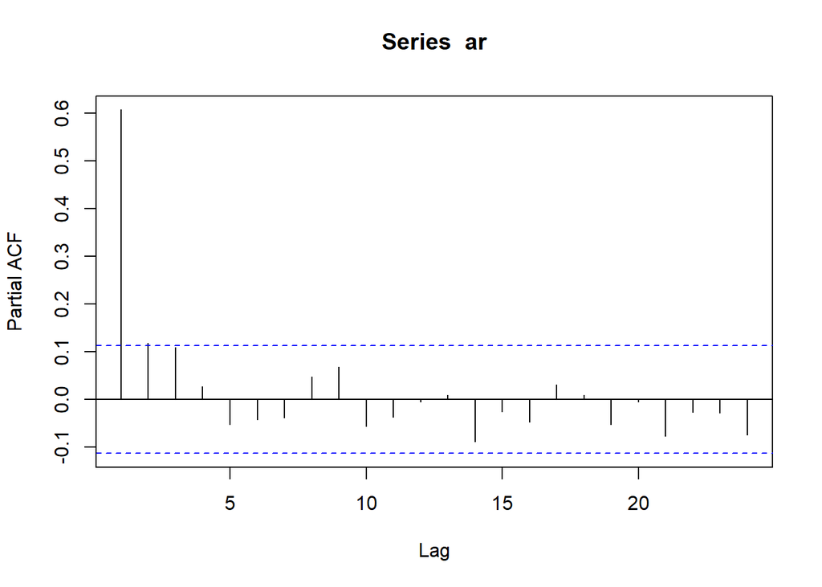

```r
pacf(ar)
```

### Plot EACF

```r
TSA::eacf(ar)
```

```
## AR/MA
##   0 1 2 3 4 5 6 7 8 9 10 11 12 13
## 0 x x x x x x o o o o o  o  o  o
## 1 x o o o o o o o o o o  o  o  o
## 2 x x o o o o o o o o o  o  o  o
## 3 x x o o o o o o o o o  o  o  o
## 4 x x x o o o o o o o o  o  o  o
## 5 x o x o o o o o o o o  o  o  o
## 6 x o x x o o o o o o o  o  o  o
## 7 x x o x x o o o o o o  o  o  o
```

## Scatterplot antar lag untuk AR(2)

### Scatterplot $Y_t$ dengan $Y_{t-1}$

```r
#Yt
yt_ar <- ar[-1]
yt_ar
```

```
##   [1]  2.000000000  0.196265494  0.535527228  1.846027209 -1.108488376
##   [6] -1.390723656 -1.635478393 -0.217049483  0.197094020 -1.293594891
##  [11] -1.533761525 -1.902883000 -0.318090266 -1.052695868 -1.700885051
##  [16] -0.083696368  1.223767377  1.207525142  0.131561274 -1.226062174
##  [21]  0.452275443 -0.258438451 -1.102669040 -2.578310013 -0.094197138
##  [26]  0.172640787  1.449135478  0.361248578  1.699275673  0.597579062
##  [31]  0.269651311  0.356596671 -0.074491996 -1.168583860  0.066408226
##  [36]  0.215244856 -0.475508598  0.464287355  2.309318817  0.130441706
##  [41]  1.098052729  0.185536243  1.383107876  0.835084597  2.829869691
##  [46]  1.907420711  0.397417130  1.532915843  1.469798304  0.871603779
##  [51]  0.695237243 -0.150183269  0.319299722  0.710017959 -1.312754863
##  [56] -1.099484820 -0.543840416  0.104241627 -1.612465871 -1.020734724
##  [61] -0.880127713  0.564966621  1.075923094 -0.051738687  0.026096329
##  [66] -0.480606971  1.160889514 -1.032853136  1.084597401  0.152518187
##  [71] -1.111374934 -1.221879581 -0.644251464 -1.364065391 -1.529105215
```

[output cut: 45 more lines]

```r
#Yt-1
yt_1_ar <- ar[-300]
yt_1_ar
```

```
##   [1]  1.000000000  2.000000000  0.196265494  0.535527228  1.846027209
##   [6] -1.108488376 -1.390723656 -1.635478393 -0.217049483  0.197094020
##  [11] -1.293594891 -1.533761525 -1.902883000 -0.318090266 -1.052695868
##  [16] -1.700885051 -0.083696368  1.223767377  1.207525142  0.131561274
##  [21] -1.226062174  0.452275443 -0.258438451 -1.102669040 -2.578310013
##  [26] -0.094197138  0.172640787  1.449135478  0.361248578  1.699275673
##  [31]  0.597579062  0.269651311  0.356596671 -0.074491996 -1.168583860
##  [36]  0.066408226  0.215244856 -0.475508598  0.464287355  2.309318817
##  [41]  0.130441706  1.098052729  0.185536243  1.383107876  0.835084597
##  [46]  2.829869691  1.907420711  0.397417130  1.532915843  1.469798304
##  [51]  0.871603779  0.695237243 -0.150183269  0.319299722  0.710017959
##  [56] -1.312754863 -1.099484820 -0.543840416  0.104241627 -1.612465871
##  [61] -1.020734724 -0.880127713  0.564966621  1.075923094 -0.051738687
##  [66]  0.026096329 -0.480606971  1.160889514 -1.032853136  1.084597401
##  [71]  0.152518187 -1.111374934 -1.221879581 -0.644251464 -1.364065391
```

[output cut: 45 more lines]

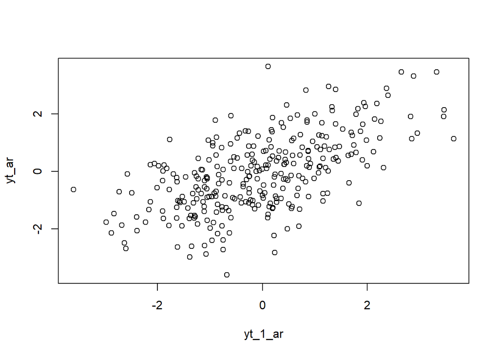

```r
plot(y=yt_ar,x=yt_1_ar)
```

Berdasarkan scatterplot tersebut, terlihat bahwa terdapat hubungan positif antara $Y_t$ dengan $Y_{t-1}$. Hal ini sesuai dengan teori yang ada

### Scatterplot $Y_t$ dengan $Y_{t-2}$

```r
#Yt
yt_ar2 <- ar[-c(1,2)]
yt_ar2
```

```
##   [1]  0.196265494  0.535527228  1.846027209 -1.108488376 -1.390723656
##   [6] -1.635478393 -0.217049483  0.197094020 -1.293594891 -1.533761525
##  [11] -1.902883000 -0.318090266 -1.052695868 -1.700885051 -0.083696368
##  [16]  1.223767377  1.207525142  0.131561274 -1.226062174  0.452275443
##  [21] -0.258438451 -1.102669040 -2.578310013 -0.094197138  0.172640787
##  [26]  1.449135478  0.361248578  1.699275673  0.597579062  0.269651311
##  [31]  0.356596671 -0.074491996 -1.168583860  0.066408226  0.215244856
##  [36] -0.475508598  0.464287355  2.309318817  0.130441706  1.098052729
##  [41]  0.185536243  1.383107876  0.835084597  2.829869691  1.907420711
##  [46]  0.397417130  1.532915843  1.469798304  0.871603779  0.695237243
##  [51] -0.150183269  0.319299722  0.710017959 -1.312754863 -1.099484820
##  [56] -0.543840416  0.104241627 -1.612465871 -1.020734724 -0.880127713
##  [61]  0.564966621  1.075923094 -0.051738687  0.026096329 -0.480606971
##  [66]  1.160889514 -1.032853136  1.084597401  0.152518187 -1.111374934
##  [71] -1.221879581 -0.644251464 -1.364065391 -1.529105215 -0.875939740
```

[output cut: 45 more lines]

```r
#Yt-2
yt_2_ar <- ar[-c(299,300)]
yt_2_ar
```

```
##   [1]  1.000000000  2.000000000  0.196265494  0.535527228  1.846027209
##   [6] -1.108488376 -1.390723656 -1.635478393 -0.217049483  0.197094020
##  [11] -1.293594891 -1.533761525 -1.902883000 -0.318090266 -1.052695868
##  [16] -1.700885051 -0.083696368  1.223767377  1.207525142  0.131561274
##  [21] -1.226062174  0.452275443 -0.258438451 -1.102669040 -2.578310013
##  [26] -0.094197138  0.172640787  1.449135478  0.361248578  1.699275673
##  [31]  0.597579062  0.269651311  0.356596671 -0.074491996 -1.168583860
##  [36]  0.066408226  0.215244856 -0.475508598  0.464287355  2.309318817
##  [41]  0.130441706  1.098052729  0.185536243  1.383107876  0.835084597
##  [46]  2.829869691  1.907420711  0.397417130  1.532915843  1.469798304
##  [51]  0.871603779  0.695237243 -0.150183269  0.319299722  0.710017959
##  [56] -1.312754863 -1.099484820 -0.543840416  0.104241627 -1.612465871
##  [61] -1.020734724 -0.880127713  0.564966621  1.075923094 -0.051738687
##  [66]  0.026096329 -0.480606971  1.160889514 -1.032853136  1.084597401
##  [71]  0.152518187 -1.111374934 -1.221879581 -0.644251464 -1.364065391
```

[output cut: 45 more lines]

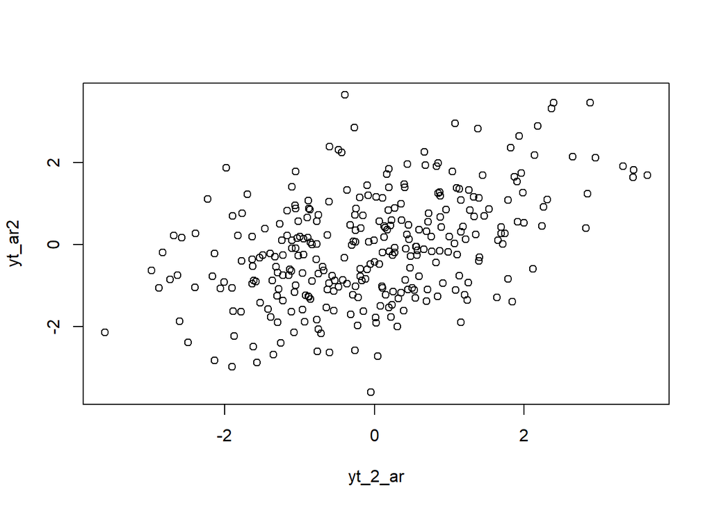

```r
plot(y=yt_ar2,x=yt_2_ar)
```

Berdasarkan scatterplot tersebut, terlihat bahwa terdapat hubungan positif antara $Y_t$ dengan $Y_{t-2}$. Hal ini sesuai dengan teori yang ada

### Scatterplot $Y_t$ dengan $Y_{t-3}$

```r
#Yt
yt_ar3 <- ar[-c(1,2,3)]
yt_ar3
```

```
##   [1]  0.535527228  1.846027209 -1.108488376 -1.390723656 -1.635478393
##   [6] -0.217049483  0.197094020 -1.293594891 -1.533761525 -1.902883000
##  [11] -0.318090266 -1.052695868 -1.700885051 -0.083696368  1.223767377
##  [16]  1.207525142  0.131561274 -1.226062174  0.452275443 -0.258438451
##  [21] -1.102669040 -2.578310013 -0.094197138  0.172640787  1.449135478
##  [26]  0.361248578  1.699275673  0.597579062  0.269651311  0.356596671
##  [31] -0.074491996 -1.168583860  0.066408226  0.215244856 -0.475508598
##  [36]  0.464287355  2.309318817  0.130441706  1.098052729  0.185536243
##  [41]  1.383107876  0.835084597  2.829869691  1.907420711  0.397417130
##  [46]  1.532915843  1.469798304  0.871603779  0.695237243 -0.150183269
##  [51]  0.319299722  0.710017959 -1.312754863 -1.099484820 -0.543840416
##  [56]  0.104241627 -1.612465871 -1.020734724 -0.880127713  0.564966621
##  [61]  1.075923094 -0.051738687  0.026096329 -0.480606971  1.160889514
##  [66] -1.032853136  1.084597401  0.152518187 -1.111374934 -1.221879581
##  [71] -0.644251464 -1.364065391 -1.529105215 -0.875939740 -1.423182334
```

[output cut: 45 more lines]

```r
#Yt-3
yt_3_ar <- ar[-c(298,299,300)]
yt_3_ar
```

```
##   [1]  1.000000000  2.000000000  0.196265494  0.535527228  1.846027209
##   [6] -1.108488376 -1.390723656 -1.635478393 -0.217049483  0.197094020
##  [11] -1.293594891 -1.533761525 -1.902883000 -0.318090266 -1.052695868
##  [16] -1.700885051 -0.083696368  1.223767377  1.207525142  0.131561274
##  [21] -1.226062174  0.452275443 -0.258438451 -1.102669040 -2.578310013
##  [26] -0.094197138  0.172640787  1.449135478  0.361248578  1.699275673
##  [31]  0.597579062  0.269651311  0.356596671 -0.074491996 -1.168583860
##  [36]  0.066408226  0.215244856 -0.475508598  0.464287355  2.309318817
##  [41]  0.130441706  1.098052729  0.185536243  1.383107876  0.835084597
##  [46]  2.829869691  1.907420711  0.397417130  1.532915843  1.469798304
##  [51]  0.871603779  0.695237243 -0.150183269  0.319299722  0.710017959
##  [56] -1.312754863 -1.099484820 -0.543840416  0.104241627 -1.612465871
##  [61] -1.020734724 -0.880127713  0.564966621  1.075923094 -0.051738687
##  [66]  0.026096329 -0.480606971  1.160889514 -1.032853136  1.084597401
##  [71]  0.152518187 -1.111374934 -1.221879581 -0.644251464 -1.364065391
```

[output cut: 45 more lines]

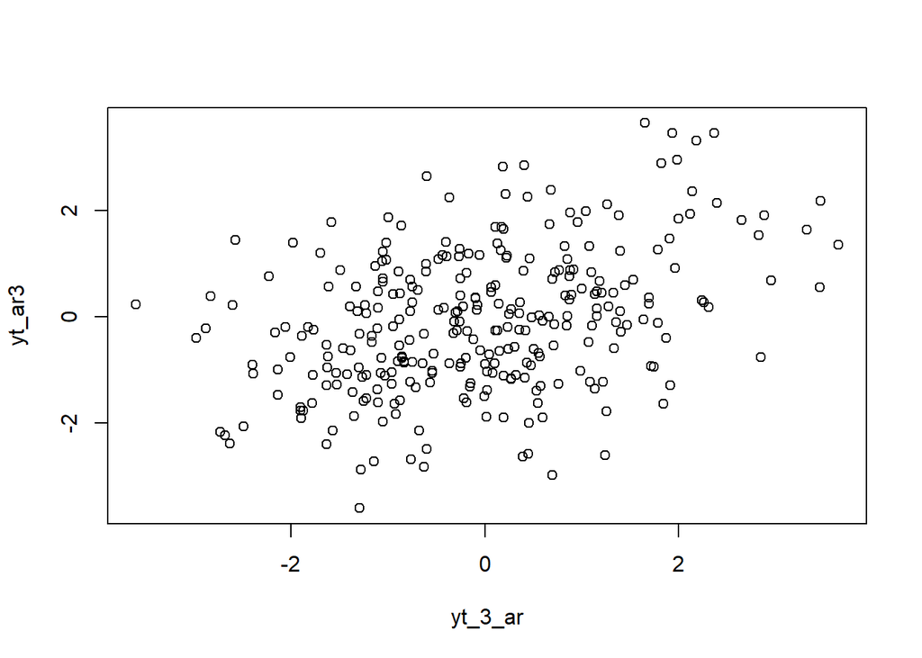

```r
plot(y=yt_ar3,x=yt_3_ar)
```

Berdasarkan scatterplot tersebut, terlihat bahwa terdapat hubungan positif antara $Y_t$ dengan $Y_{t-3}$. Hal ini sesuai dengan teori yang ada

## Autokorelasi pada AR(2)

```r
cor(yt_ar,yt_1_ar)
```

```
## [1] 0.6073404
```

```r
cor(yt_ar2,yt_2_ar)
```

```
## [1] 0.4455152
```

```r
cor(yt_ar3,yt_3_ar)
```

```
## [1] 0.3787938
```

Korelasi antara $Y_t$ dengan $Y_{t-1}$ dari hasil simulasi mendekati perhitungan teoritis yaitu
$$\rho_1=\frac{\phi_1}{1-\phi_2}=\frac{0.5}{1-0.2}=0.63$$
Korelasi antara $Y_t$ dengan $Y_{t-2}$ dari hasil simulasi mendekati perhitungan teoritis yaitu
$$\rho_2=\frac{\phi_2(1-\phi_2)+\phi_1^2}{1-\phi_2}=\frac{0.2\times(1-0.2)+0.5^2}{1-0.2}=0.51$$

Mencari korelasi antara $Y_t$ dengan $Y_{t-3}$ Berikut dicari terlebih dahulu rumusnya:
$$\rho_3=\phi_1\rho_2+\phi_2\rho_1=\phi_1(\frac{\phi_2(1-\phi_2)+\phi_1^2}{1-\phi_2})+\phi_2(\frac{\phi_1}{1-\phi_2})$$
Apabila dilakukan penyederhanaan maka akan didapatkan rumus berikut: Sehingga korelasi antara $Y_t$ dengan $Y_{t-3}$ dari hasil simulasi mendekati perhitungan teoritis yaitu
$$\rho_3=\frac{\phi_1^3+2\phi_1\phi_2-\phi_1\phi_2^2}{1-\phi_2}=\frac{0.5^3+2\times0.5\times0.2-0.5\times0.2^2}{1-0.2}=0.38$$

## Plot, Scatterplot, Autokorelasi: AR(2) dengan ARIMA.SIM

### Plot ARIMA.SIM AR(2)

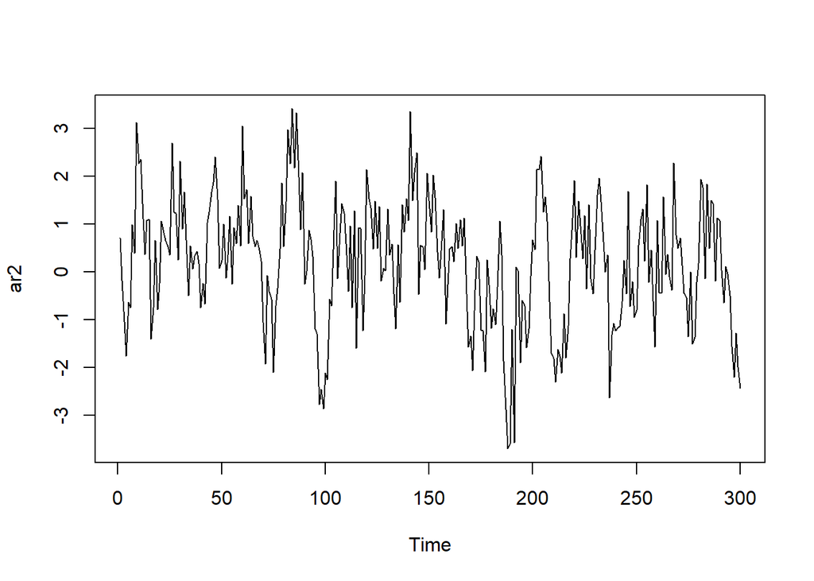

```r
ts.plot(ar2) #Plot Time Series
```

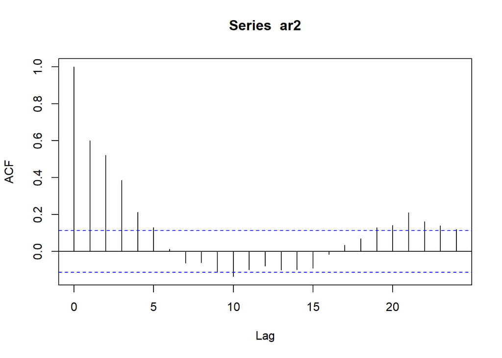

```r
acf(ar2) #Plot ACF
```

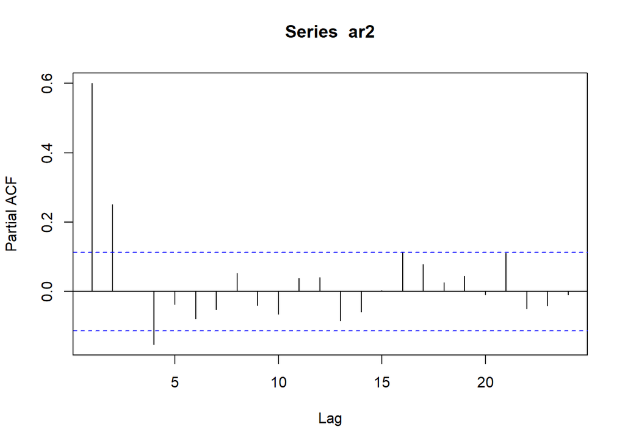

```r
pacf(ar2) #Plot PACF
```

```r
TSA::eacf(ar2) #Plot EACF
```

```
## AR/MA
##   0 1 2 3 4 5 6 7 8 9 10 11 12 13
## 0 x x x x x o o o o x o  o  o  o
## 1 x x x o x o o o o o o  o  o  o
## 2 o x x o x o o o o o o  o  o  o
## 3 o x x x x o x o o o o  o  o  o
## 4 x x o x o o o o o o o  o  o  o
## 5 x x o x o o o o o o o  o  o  o
## 6 x x x o o o o o o o o  o  o  o
## 7 x o x o o o o o o o o  o  o  o
```

### Scattlerplot dan autokorelasi antar lag ARIMA.SIM AR(2)

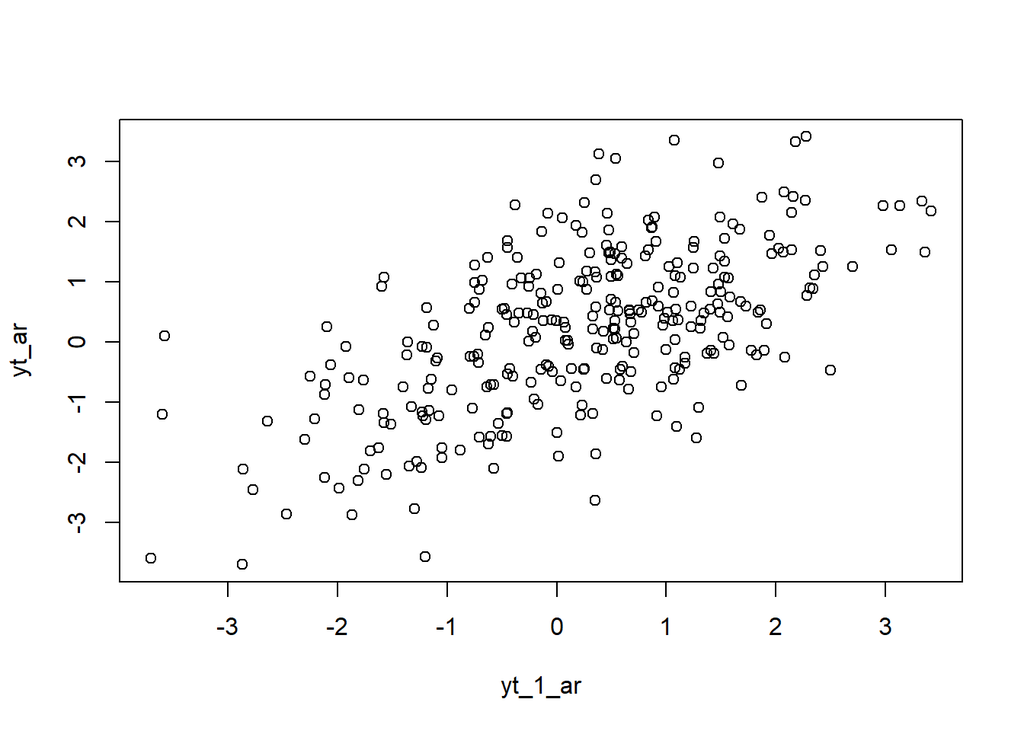

```r
#Korelasi antara Yt dengan Yt−1
yt_ar <- ar2[-1]
yt_1_ar <- ar2[-300]
plot(y=yt_ar,x=yt_1_ar)
```

```r
cor(yt_ar,yt_1_ar)
```

```
## [1] 0.6042954
```

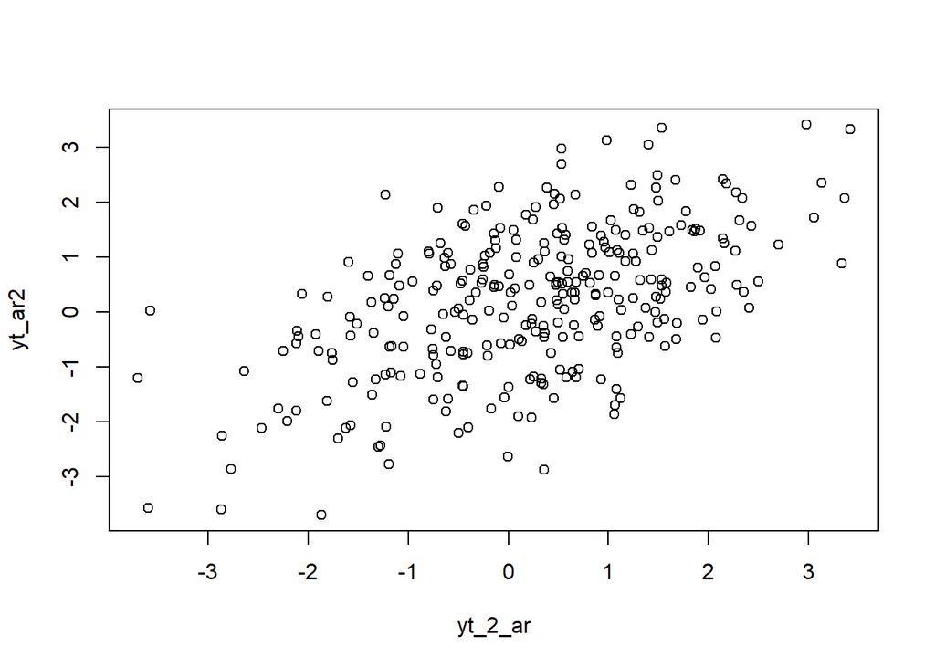

```r
#Korelasi antara Yt dengan Yt−2
yt_ar2 <- ar2[-c(1,2)]
yt_2_ar <- ar2[-c(299,300)]
plot(y=yt_ar2,x=yt_2_ar)
```

```r
cor(yt_ar2,yt_2_ar)
```

```
## [1] 0.5268542
```

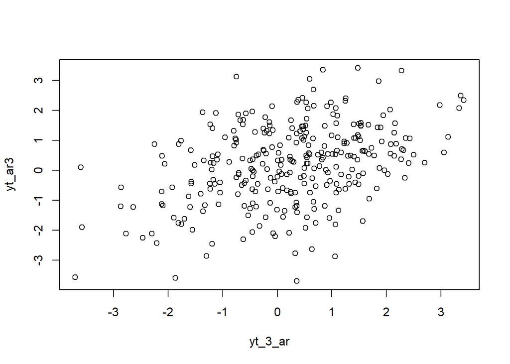

```r
#Korelasi antara Yt dengan Yt−3
yt_ar3 <- ar2[-c(1,2,3)]
yt_3_ar <- ar2[-c(298,299,300)]
plot(y=yt_ar3,x=yt_3_ar)
```

```r
cor(yt_ar3,yt_3_ar)
```

```
## [1] 0.3912468
```

## Proses ARMA (2,2)

Setelah mengetahui cara membangkitkan data berpola AR, MA, dan ARMA sederhana, bagaimana cara melakukan pembangkitan data berpola tersebut yang lebih kompleks? Apakah dapat dibuat suatu fungsi yang fleksibel yang memungkinan pembangkitan dengan berapapun jumlah koefisien?

### Pembangkitan secara manual untuk ARMA(2,2)

Pertama, lihat kembali bentuk umum data berpola ARMA.

$$y_{t} = c + \sum_{i=1}^p \phi_{i}y_{t-i} + \sum_{j=1}^q e_{t-j}+ e_{t}$$
Jika koefisien dan *white noise*/nilai deret waktu sebelumnya dapat diekstrak dalam bentuk vektor, dapat dilakukan perkalian matriks untuk mencari nilai bagian AR dan MA:

#Ingat perintah SOAL:

#Pembentukan Model ARMA(2,2) dengan $\phi$ (untuk AR) = 0.5 dan 0.2 dan $\theta$ (untuk MA)=0.4 dan 0.6

```r
set.seed(30)
coefs <- c(0.4, 0.6, 0.5, 0.2)
e <- c(1, 2, 3, 4)

coefs %*% e
```

```
##      [,1]
## [1,]  3.9
```

Atau, dapat dilakukan perkalian *elementwise* yang dijumlahkan:

```r
coefs * e
```

```
## [1] 0.4 1.2 1.5 0.8
```

```r
sum(coefs * e)
```

```
## [1] 3.9
```

Dari prinsip ini, dapat dibuat fungsi umum untuk membangkitkan data ARMA. Input dari fungsi adalah jumlah data yang hendak dibangkitkan, koefisien MA, dan koefisien AR.

```r
arma.sim <- function(n, macoef, arcoef){
  manum <- length(macoef)
  arnum <- length(arcoef)
  stopifnot(manum < n & arnum < n)

  wn <- rnorm(n, sd = 0.5)
  init <- max(manum, arnum)

  arma <- wn[1:init]
  for(i in {init+1}:n){
   mastart <- i - manum
   maend <- i-1
   arstart <- i - arnum
   arend <- i-1
   arma[i] <- sum(arcoef * arma[arstart:arend]) + sum(macoef * wn[mastart:maend])  + wn[i]
   }
  return(arma)
}
```

Terlihat bahwa komponen $\sum_{i=1}^q y_{t-1}$ disimulasikan melalui `sum(arcoef * arma[arstart:arend])`. Jadi, koefisien dikalikan dengan data $y$ dari $t-q$ di mana q adalah jumlah koefisien AR, sampai data $t-1$. Lalu komponen $\sum_{j=1}^q e_{t-j}$ disimulasikan melalui `sum(macoef * wn[mastart:maend])`. Koefisien dikalikan dengan *white noise* $e$ dari $t-p$, p jumlah koefisien MA, sampai $t-1$.

```r
#contoh untuk ARMA
set.seed(064)
arma22 <- arma.sim(300, c(0.4, 0.6), c(0.5,0.2))

arma22 |> arima(c(2,0,2))
```

```
##
## Call:
## arima(x = arma22, order = c(2, 0, 2))
##
## Coefficients:
##          ar1     ar2     ma1     ma2  intercept
##       0.3035  0.3884  0.4577  0.4406     0.1708
## s.e.  0.0944  0.0897  0.0894  0.0623     0.1782
##
## sigma^2 estimated as 0.2575:  log likelihood = -223.14,  aic = 458.27
```

```r
set.seed(064)
n = length(wn)
phi1 = 0.5
phi2 = 0.2
theta1 = 0.4
theta2 = 0.6

y.arma=c(1:n)
for (i in 3:n){y.arma[i] = phi1*y.arma[i-1]+ phi2*y.arma[i-2] + theta1*wn[i-1] + theta2*wn[i-2]+wn[i]}
```

Pembangkitan ARMA(p,q) juga dapat dilakukan dengan fungsi `arima.sim` sebagai berikut.

```r
set.seed(064)
arma11 <- arima.sim(list(order=c(2,0,2), ar = c(0.5,0.2), ma = c(0.4,0.6)), n=300)
arma11
```

```
## Time Series:
## Start = 1
## End = 300
## Frequency = 1
##   [1] -0.686977232 -2.282303914 -1.965795473 -2.060282063  0.303812344
##   [6]  0.332795992  3.877718744  3.755501710  5.142950268  3.416131698
##  [11]  2.220326922  1.892754617  1.747214661 -0.314099848 -0.651379007
##  [16] -0.487120457 -0.979182057 -0.170876036  0.495268717  1.096942620
##  [21]  1.630877018  1.290071188  0.968031353  3.165187967  2.545762886
##  [26]  3.345336320  1.491965647  3.147950422  1.982062827  3.425850483
##  [31]  1.888906152  0.780164446  0.752666033 -0.016358112  0.683453786
##  [36]  0.600206122  0.544766625 -0.424262398 -0.431102521 -1.220311223
##  [41]  0.617045725  1.260349299  2.789688999  3.296682708  4.163192400
##  [46]  3.610293451  2.133884200  1.183653594  1.141319786  0.418311746
##  [51]  0.899770022  1.236380080  0.423252271  1.529672103  0.809448999
```

[output cut: 49 more lines]

## Karakteristik ARMA(2,2)

### Plot Time Series

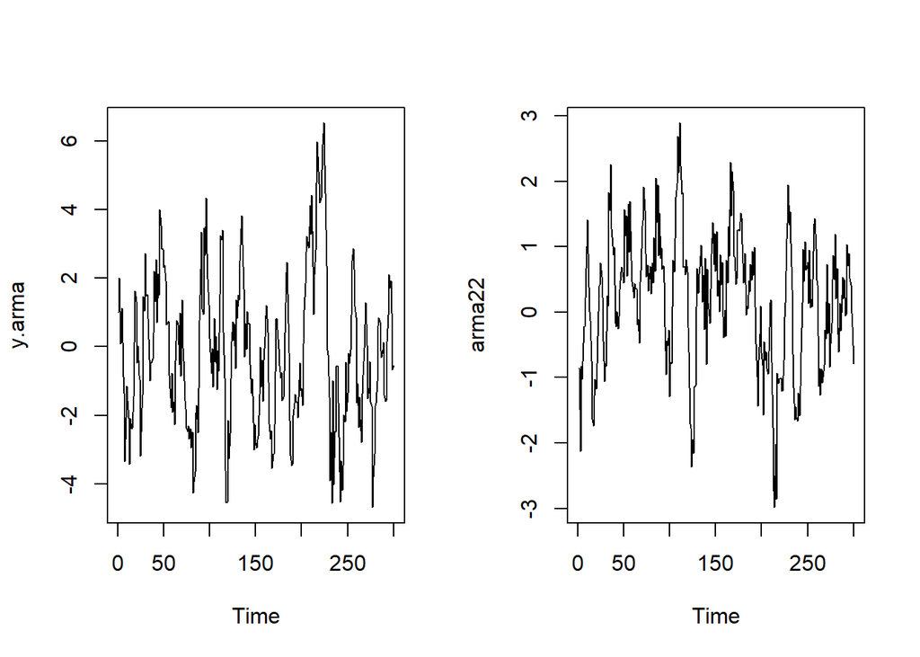

```r
par(mfrow = c(1, 2))
ts.plot(y.arma)
ts.plot(arma22)
```

```r
par(mfrow = c(1, 1))
```

Berdasarkan plot time series tersebut, terlihat bahwa model ARMA(2,2) cenderung stasioner dalam rataan

### Plot ACF

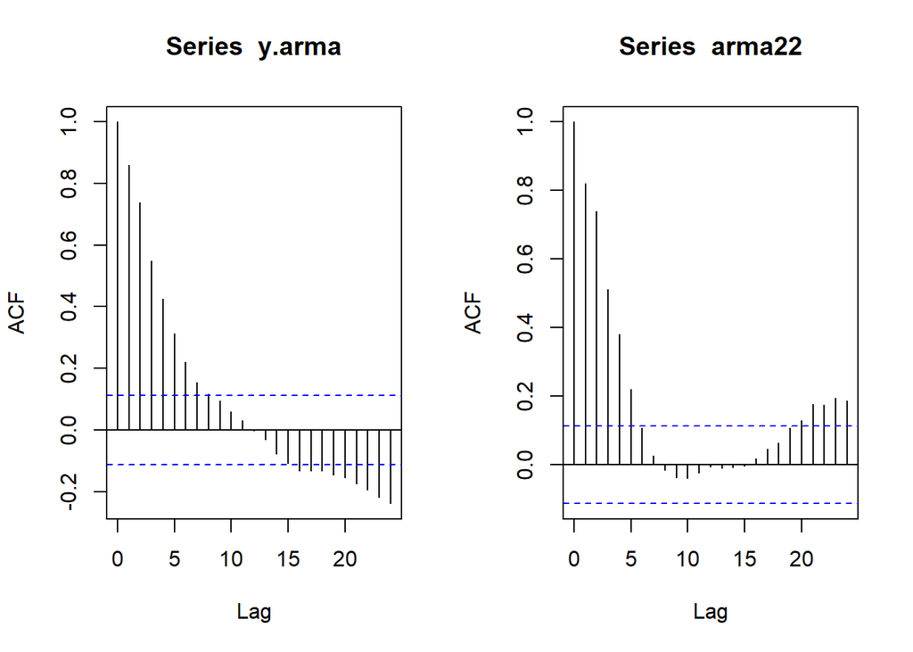

```r
par(mfrow = c(1, 2))
acf(y.arma)
acf(arma22)
```

```r
par(mfrow = c(1, 1))
```

Berdasarkan plot ACF tersebut, terlihat bahwa model ARMA(2,2) hasil simulasi memiliki plot ACF yang *tails off*, sesuai dengan teori yang ada

### Plot PACF

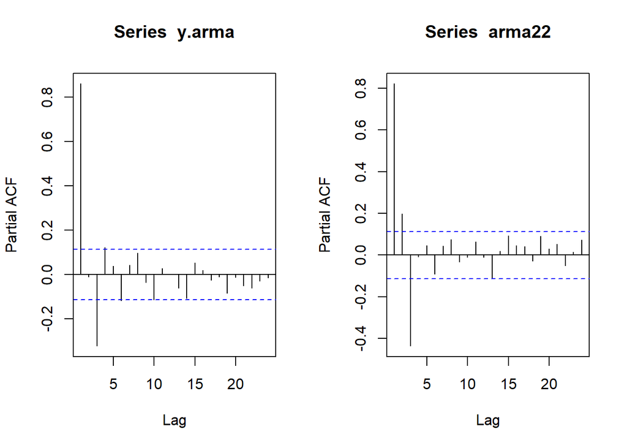

```r
par(mfrow = c(1, 2))
pacf(y.arma)
pacf(arma22)
```

```r
par(mfrow = c(1, 1))
```

Berdasarkan plot PACF tersebut, terlihat bahwa model ARMA(2,2) hasil simulasi memiliki plot PACF yang *tails off*, sesuai dengan teori

### Plot EACF

```r
TSA::eacf(y.arma)
```

```
## AR/MA
##   0 1 2 3 4 5 6 7 8 9 10 11 12 13
## 0 x x x x x x x o o o o  o  o  o
## 1 o x o o o o o o o o o  o  o  o
## 2 o x x o o o o o o o o  o  o  o
## 3 x x x x o o o o o o o  o  o  o
## 4 x x x x o o o o o o o  o  o  o
## 5 x x o x o o o o o o o  o  o  o
## 6 x x x x o o o o o o o  o  o  o
## 7 x x x o o o o o o o o  o  o  o
```

```r
TSA::eacf(arma22)
```

```
## AR/MA
##   0 1 2 3 4 5 6 7 8 9 10 11 12 13
## 0 x x x x x o o o o o o  o  o  o
## 1 x x o x o o o o o o o  o  o  o
## 2 x x x x o o o o o o o  o  o  o
## 3 o o x x o o o o o o o  o  o  o
## 4 x o x x x o o o o o o  o  o  o
## 5 x o o x x o o o o o o  o  o  o
## 6 x x x x o o o o o o o  o  o  o
## 7 x x x o o o o o o o o  o  o  o
```

## Scatterplot antar lag untuk ARMA(2,2)

### Korelasi antara $Y_t$ dengan $Y_{t-1}$

```r
#Yt
yt_arma <- arma11[-1]
yt_arma
```

```
##   [1] -2.282303914 -1.965795473 -2.060282063  0.303812344  0.332795992
##   [6]  3.877718744  3.755501710  5.142950268  3.416131698  2.220326922
##  [11]  1.892754617  1.747214661 -0.314099848 -0.651379007 -0.487120457
##  [16] -0.979182057 -0.170876036  0.495268717  1.096942620  1.630877018
##  [21]  1.290071188  0.968031353  3.165187967  2.545762886  3.345336320
##  [26]  1.491965647  3.147950422  1.982062827  3.425850483  1.888906152
##  [31]  0.780164446  0.752666033 -0.016358112  0.683453786  0.600206122
##  [36]  0.544766625 -0.424262398 -0.431102521 -1.220311223  0.617045725
##  [41]  1.260349299  2.789688999  3.296682708  4.163192400  3.610293451
##  [46]  2.133884200  1.183653594  1.141319786  0.418311746  0.899770022
##  [51]  1.236380080  0.423252271  1.529672103  0.809448999  2.193964482
##  [56]  1.455250639  4.112393155  3.076346809  4.173404377  2.202797066
##  [61]  2.857683255  1.739260699  1.787037146  1.327794613  1.107745028
##  [66]  0.837896170 -0.641678435 -2.201286296 -1.472605602 -1.582711295
##  [71] -0.779611630 -2.576115089 -1.902154269 -1.895403057 -0.090957650
```

[output cut: 45 more lines]

```r
#Yt-1
yt_1_arma <- arma11[-300]
yt_1_arma
```

```
##   [1] -0.686977232 -2.282303914 -1.965795473 -2.060282063  0.303812344
##   [6]  0.332795992  3.877718744  3.755501710  5.142950268  3.416131698
##  [11]  2.220326922  1.892754617  1.747214661 -0.314099848 -0.651379007
##  [16] -0.487120457 -0.979182057 -0.170876036  0.495268717  1.096942620
##  [21]  1.630877018  1.290071188  0.968031353  3.165187967  2.545762886
##  [26]  3.345336320  1.491965647  3.147950422  1.982062827  3.425850483
##  [31]  1.888906152  0.780164446  0.752666033 -0.016358112  0.683453786
##  [36]  0.600206122  0.544766625 -0.424262398 -0.431102521 -1.220311223
##  [41]  0.617045725  1.260349299  2.789688999  3.296682708  4.163192400
##  [46]  3.610293451  2.133884200  1.183653594  1.141319786  0.418311746
##  [51]  0.899770022  1.236380080  0.423252271  1.529672103  0.809448999
##  [56]  2.193964482  1.455250639  4.112393155  3.076346809  4.173404377
##  [61]  2.202797066  2.857683255  1.739260699  1.787037146  1.327794613
##  [66]  1.107745028  0.837896170 -0.641678435 -2.201286296 -1.472605602
##  [71] -1.582711295 -0.779611630 -2.576115089 -1.902154269 -1.895403057
```

[output cut: 45 more lines]

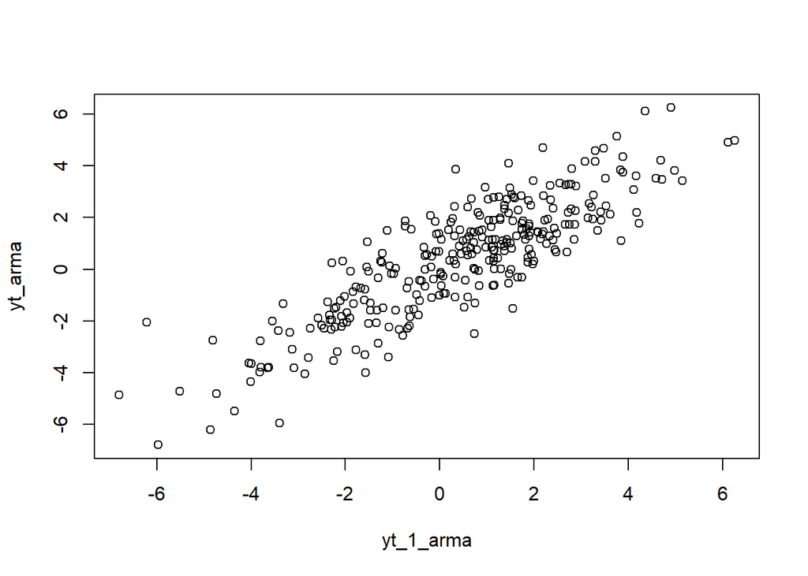

```r
plot(y=yt_arma,x=yt_1_arma)
```

Berdasarkan scatterplot tersebut, terlihat bahwa terdapat hubungan positif antara $Y_t$ dengan $Y_{t-1}$. Hal ini sesuai dengan teori yang ada

### Korelasi antara $Y_t$ dengan $Y_{t-2}$

```r
#Yt
yt_arma2 <- arma11[-c(1,2)]
yt_arma2
```

```
##   [1] -1.965795473 -2.060282063  0.303812344  0.332795992  3.877718744
##   [6]  3.755501710  5.142950268  3.416131698  2.220326922  1.892754617
##  [11]  1.747214661 -0.314099848 -0.651379007 -0.487120457 -0.979182057
##  [16] -0.170876036  0.495268717  1.096942620  1.630877018  1.290071188
##  [21]  0.968031353  3.165187967  2.545762886  3.345336320  1.491965647
##  [26]  3.147950422  1.982062827  3.425850483  1.888906152  0.780164446
##  [31]  0.752666033 -0.016358112  0.683453786  0.600206122  0.544766625
##  [36] -0.424262398 -0.431102521 -1.220311223  0.617045725  1.260349299
##  [41]  2.789688999  3.296682708  4.163192400  3.610293451  2.133884200
##  [46]  1.183653594  1.141319786  0.418311746  0.899770022  1.236380080
##  [51]  0.423252271  1.529672103  0.809448999  2.193964482  1.455250639
##  [56]  4.112393155  3.076346809  4.173404377  2.202797066  2.857683255
##  [61]  1.739260699  1.787037146  1.327794613  1.107745028  0.837896170
##  [66] -0.641678435 -2.201286296 -1.472605602 -1.582711295 -0.779611630
##  [71] -2.576115089 -1.902154269 -1.895403057 -0.090957650  1.844396085
```

[output cut: 45 more lines]

```r
#Yt-1
yt_2_arma <- arma11[-c(299,300)]
yt_2_arma
```

```
##   [1] -0.686977232 -2.282303914 -1.965795473 -2.060282063  0.303812344
##   [6]  0.332795992  3.877718744  3.755501710  5.142950268  3.416131698
##  [11]  2.220326922  1.892754617  1.747214661 -0.314099848 -0.651379007
##  [16] -0.487120457 -0.979182057 -0.170876036  0.495268717  1.096942620
##  [21]  1.630877018  1.290071188  0.968031353  3.165187967  2.545762886
##  [26]  3.345336320  1.491965647  3.147950422  1.982062827  3.425850483
##  [31]  1.888906152  0.780164446  0.752666033 -0.016358112  0.683453786
##  [36]  0.600206122  0.544766625 -0.424262398 -0.431102521 -1.220311223
##  [41]  0.617045725  1.260349299  2.789688999  3.296682708  4.163192400
##  [46]  3.610293451  2.133884200  1.183653594  1.141319786  0.418311746
##  [51]  0.899770022  1.236380080  0.423252271  1.529672103  0.809448999
##  [56]  2.193964482  1.455250639  4.112393155  3.076346809  4.173404377
##  [61]  2.202797066  2.857683255  1.739260699  1.787037146  1.327794613
##  [66]  1.107745028  0.837896170 -0.641678435 -2.201286296 -1.472605602
##  [71] -1.582711295 -0.779611630 -2.576115089 -1.902154269 -1.895403057
```

[output cut: 45 more lines]

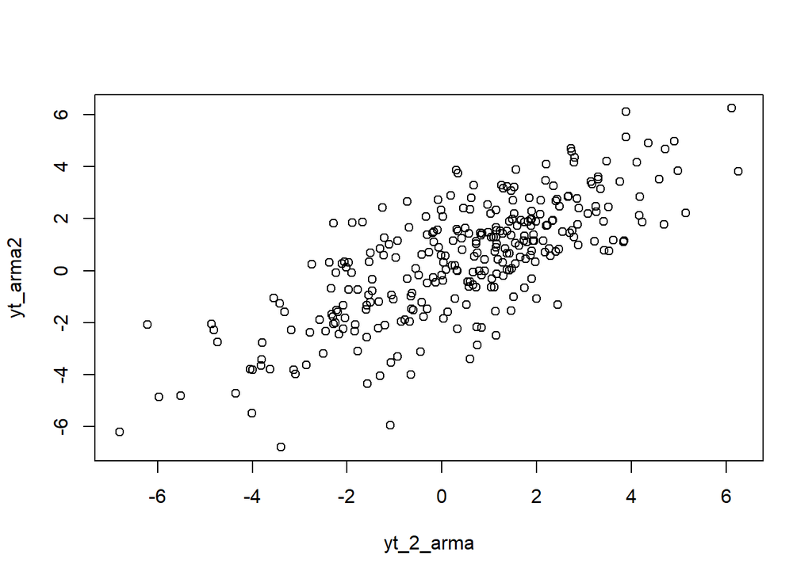

```r
plot(y=yt_arma2,x=yt_2_arma)
```

Berdasarkan scatterplot tersebut, terlihat bahwa terdapat hubungan positif antara $Y_t$ dengan $Y_{t-2}$. Hal ini sesuai dengan teori yang ada

### Korelasi antara $Y_t$ dengan $Y_{t-3}$

```r
#Yt
yt_arma3 <- arma11[-c(1,2,3)]
yt_arma3
```

```
##   [1] -2.060282063  0.303812344  0.332795992  3.877718744  3.755501710
##   [6]  5.142950268  3.416131698  2.220326922  1.892754617  1.747214661
##  [11] -0.314099848 -0.651379007 -0.487120457 -0.979182057 -0.170876036
##  [16]  0.495268717  1.096942620  1.630877018  1.290071188  0.968031353
##  [21]  3.165187967  2.545762886  3.345336320  1.491965647  3.147950422
##  [26]  1.982062827  3.425850483  1.888906152  0.780164446  0.752666033
##  [31] -0.016358112  0.683453786  0.600206122  0.544766625 -0.424262398
##  [36] -0.431102521 -1.220311223  0.617045725  1.260349299  2.789688999
##  [41]  3.296682708  4.163192400  3.610293451  2.133884200  1.183653594
##  [46]  1.141319786  0.418311746  0.899770022  1.236380080  0.423252271
##  [51]  1.529672103  0.809448999  2.193964482  1.455250639  4.112393155
##  [56]  3.076346809  4.173404377  2.202797066  2.857683255  1.739260699
##  [61]  1.787037146  1.327794613  1.107745028  0.837896170 -0.641678435
##  [66] -2.201286296 -1.472605602 -1.582711295 -0.779611630 -2.576115089
##  [71] -1.902154269 -1.895403057 -0.090957650  1.844396085  1.564056631
```

[output cut: 45 more lines]

```r
#Yt-1
yt_3_arma <- arma11[-c(288,299,300)]
yt_3_arma
```

```
##   [1] -0.686977232 -2.282303914 -1.965795473 -2.060282063  0.303812344
##   [6]  0.332795992  3.877718744  3.755501710  5.142950268  3.416131698
##  [11]  2.220326922  1.892754617  1.747214661 -0.314099848 -0.651379007
##  [16] -0.487120457 -0.979182057 -0.170876036  0.495268717  1.096942620
##  [21]  1.630877018  1.290071188  0.968031353  3.165187967  2.545762886
##  [26]  3.345336320  1.491965647  3.147950422  1.982062827  3.425850483
##  [31]  1.888906152  0.780164446  0.752666033 -0.016358112  0.683453786
##  [36]  0.600206122  0.544766625 -0.424262398 -0.431102521 -1.220311223
##  [41]  0.617045725  1.260349299  2.789688999  3.296682708  4.163192400
##  [46]  3.610293451  2.133884200  1.183653594  1.141319786  0.418311746
##  [51]  0.899770022  1.236380080  0.423252271  1.529672103  0.809448999
##  [56]  2.193964482  1.455250639  4.112393155  3.076346809  4.173404377
##  [61]  2.202797066  2.857683255  1.739260699  1.787037146  1.327794613
##  [66]  1.107745028  0.837896170 -0.641678435 -2.201286296 -1.472605602
##  [71] -1.582711295 -0.779611630 -2.576115089 -1.902154269 -1.895403057
```

[output cut: 45 more lines]

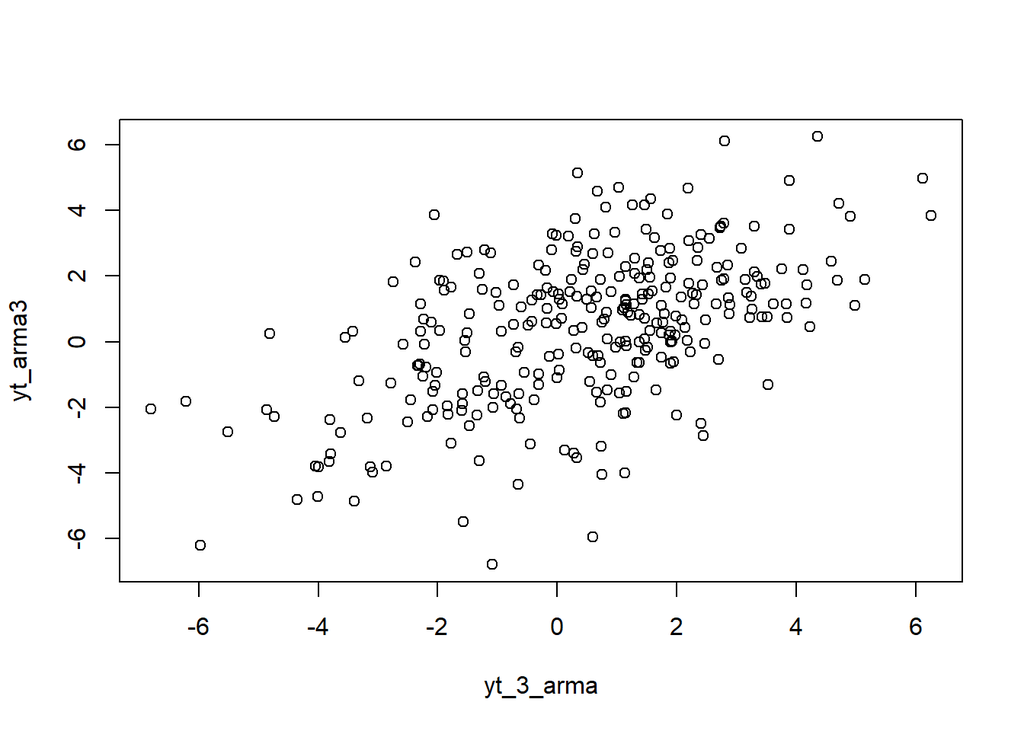

```r
plot(y=yt_arma3,x=yt_3_arma)
```

Berdasarkan scatterplot tersebut, terlihat bahwa terdapat hubungan positif antara $Y_t$ dengan $Y_{t-3}$. Hal ini sesuai dengan teori yang ada

## Autokolerasi pada ARMA(2,2)

```r
cor(yt_arma,yt_1_arma)
```

```
## [1] 0.8546989
```

```r
cor(yt_arma2,yt_2_arma)
```

```
## [1] 0.7483096
```

```r
cor(yt_arma3,yt_3_arma)
```

```
## [1] 0.5345997
```